# Data Analysis

This document analyzes and tries to find insights from WeRateDogs Twitter Archive's filtered tweets. The dataset used in this document was prepared and cleaned in wrangle_act notebook in the project folder.

First, let's look at the distributions of dog stages across the dataframe. To do this I am only going to take the rows with non-null dog stage columns. We can just assume that it is a sample from our dataset population.

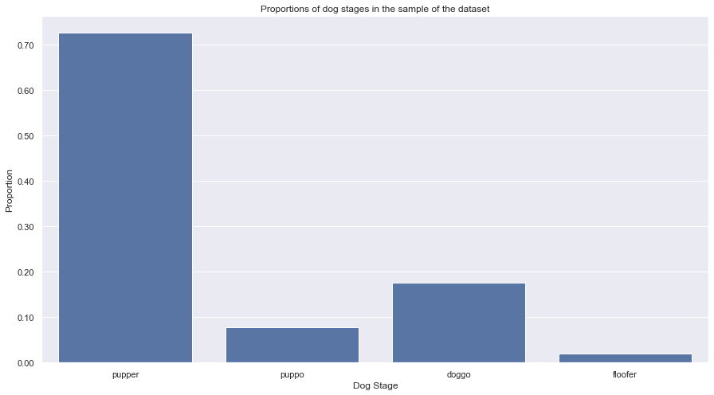

```python
# It might be a good idea to plot the proportions of dog stages instead
plt.figure(figsize=[15, 8])
number_of_dogs = non_null_df.shape[0]
max_prop = non_null_df.dog_stage.value_counts().values.max() / number_of_dogs
yticks = np.arange(0, max_prop + 0.05, 0.1)
tick_labels = ['{0:.2f}'.format(v) for v in yticks]
sns.countplot(data=non_null_df, x='dog_stage', color=base_color)
plt.xlabel('Dog Stage')
plt.ylabel('Proportion')
plt.title('Proportions of dog stages in the sample of the dataset')
plt.yticks(yticks * number_of_dogs, tick_labels);
```

Now, let's look at the relationship between dog stage and the ratings they got:

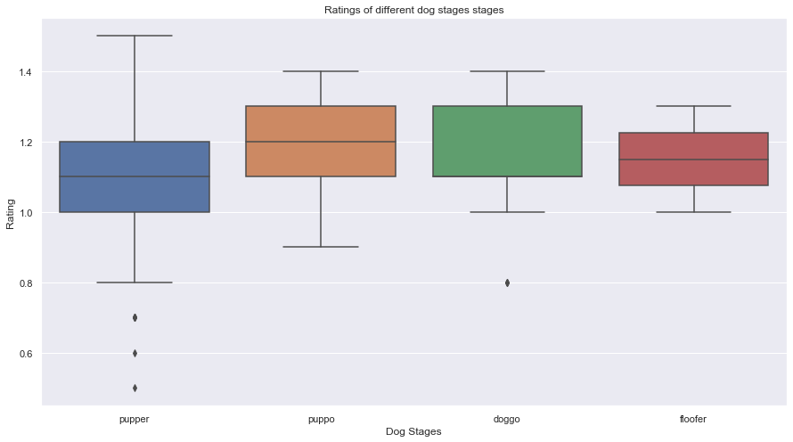

```python
plt.figure(figsize=[15, 8])
sns.boxplot(non_null_df.dog_stage, non_null_df.rating.apply(eval))
plt.title('Ratings of different dog stages stages')
plt.ylabel('Rating')
plt.xlabel('Dog Stages');
```

Now, let's explore the popularity of the dogs in different stages by using their number of "likes" and number of retweets.

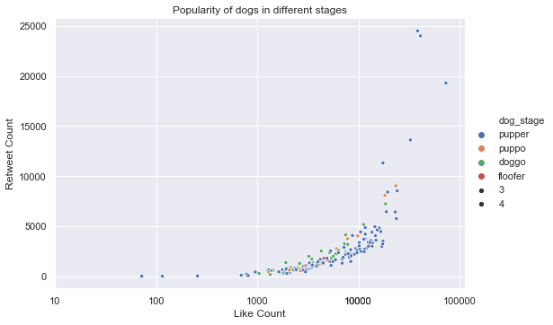

```python
sns.relplot(data=non_null_df, x='favorites', y='retweets',
            hue='dog_stage', aspect=1.5, size=4)
plt.xscale('log')
xticks = [10, 100, 1000, 10000, 10000, 100000]
plt.xticks(xticks, xticks)
plt.title('Popularity of dogs in different stages')
plt.xlabel('Like Count')
plt.ylabel('Retweet Count');
```

As can be seen from above, most popular dogs were from the pupper stage. Also, this is not because they were greater in numbers but they actually do have like counts close to 100k and had been retweeted more than 20k times.

As a final point, the visualisations and conslusions in this presentation are only based on the small sample at hand. In the actual channel, the ratings are solely based on the "cuteness" of the dogs. For this reason, the ratings and popularity of the dogs would be hugely biased, making fitting correct models to predict the rating practically impossible.